# Regresiones Lineales - Ejemplo Calificadoras

#### Paquetes

```r
#install.packages("R2OpenBUGS")
#install.packages("R2jags")
```

#### Librerias

```r
library(R2OpenBUGS)
library(R2jags)
```

#### -Working directory-

```r
wdir<-"/Users/guillemontanari/ITAM/github/GLM2016/RegresionLinealJAGS"
setwd(wdir)
```

### Funciones Útiles

```r
prob<-function(x){
  out<-min(length(x[x>0])/length(x),length(x[x<0])/length(x))
  out
}
```

### Leemos los datos de un archivo txt

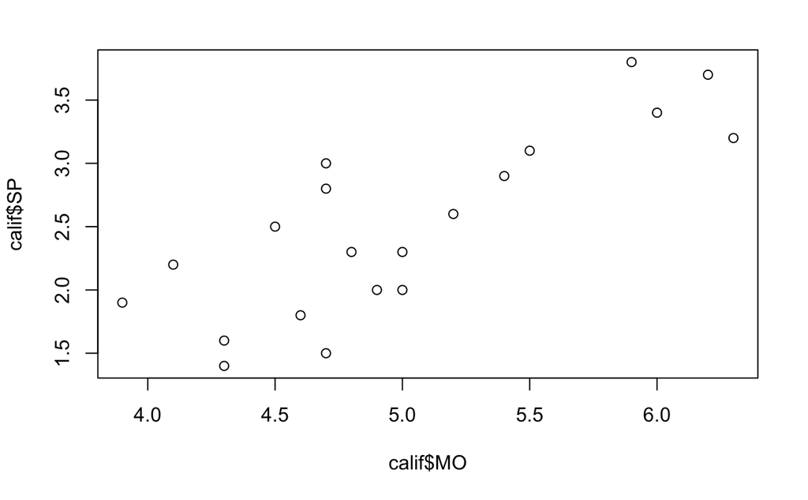

```r
#--- Ejemplo 3 ---
#-Reading data-
calif<-read.table("http://allman.rhon.itam.mx/~lnieto/index_archivos/calificaciones.txt",header=TRUE)
n<-nrow(calif)
plot(calif$MO, calif$SP)
```

### Defining data - siempre como lista para JAGS

```r
data<-list("n"=n,"y"=calif$SP,"x"=calif$MO)
```

### Defining inits

```r
inits<-function(){list(beta=rep(0,2),tau=1,yf=rep(0,n))}
```

### Defining parametros a monitorear

```r
parameters<-c("beta","tau","yf")
```

### Ejecutamos la simulacion

```r
ej3.sim<-jags(data,inits,parameters,model.file="Ej3_b.txt",
              n.iter=100000,n.chains=1,n.burnin=10000,n.thin=1)
```

### Monitoreamos la cadena

#### Traza

```r
#traceplot(ej3.sim)
```

#### Cadena

```r
out<-ej3.sim$BUGSoutput$sims.list
# Guardo los valores de Beta2 en Z: Beta2 son los coeficientes asociados a las x2 que es la pendiente
z<-out$beta[,2]
# Defino 4 zonas de ploteo
par(mfrow=c(2,2))
plot(z,type="l")
plot(cumsum(z)/(1:length(z)),type="l")
```

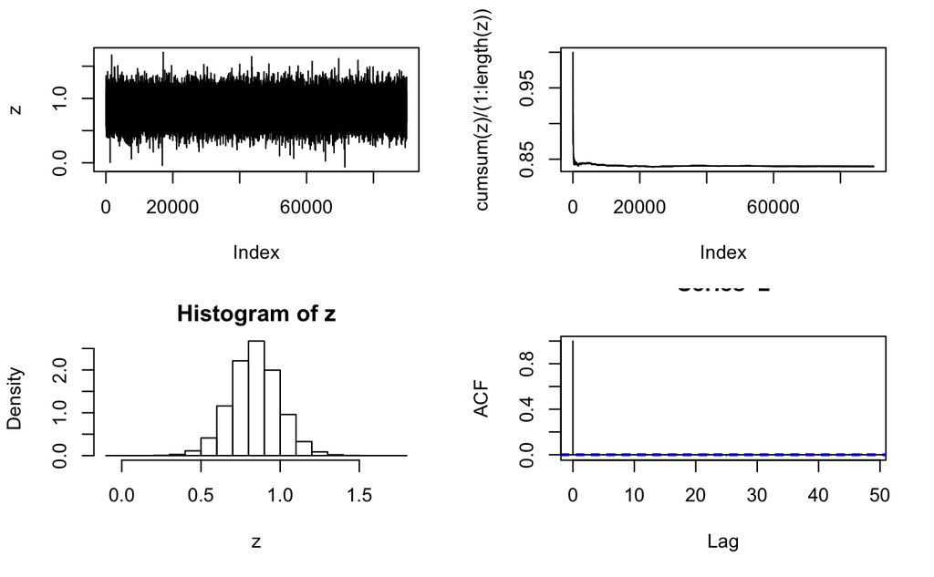

```r
hist(z,freq=FALSE)
acf(z)
```

### En la distribucion final de Beta2, la pendiente en este modelo, cercana a 0.9. Estoy alejada del cero, entonces mi coeficiente de la pendiente es significativamente distinta de cero. Mi histograma no tiene huecos, por lo tanto esta es una muestra de la distribucion que puedo tomar para hacer inferencias

### Hago lo mismo para Bet1, la ordenada al origen

```r
z<-out$beta[,1]
# Defino 4 zonas de ploteo
par(mfrow=c(2,2))
plot(z,type="l")
plot(cumsum(z)/(1:length(z)),type="l")
```

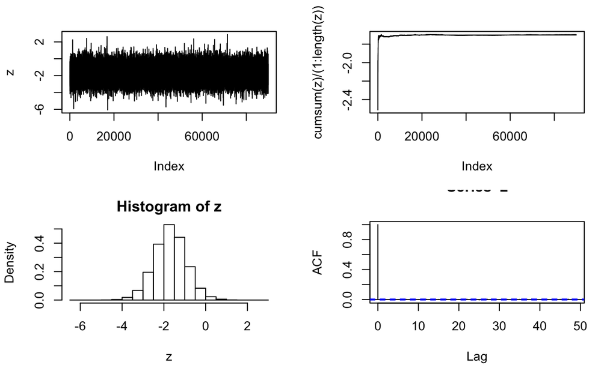

```r
hist(z,freq=FALSE)
acf(z)
```

### Beta1, toma valores alrededor de -2, esta mordiendo un poquito el cero.

### Correlacion entre Beta1 y Beta2

```r
z<-out$beta
# Defino 1 zona de ploteo
par(mfrom=c(1,1))
```

```
"mfrom" is not a graphical parameter
```

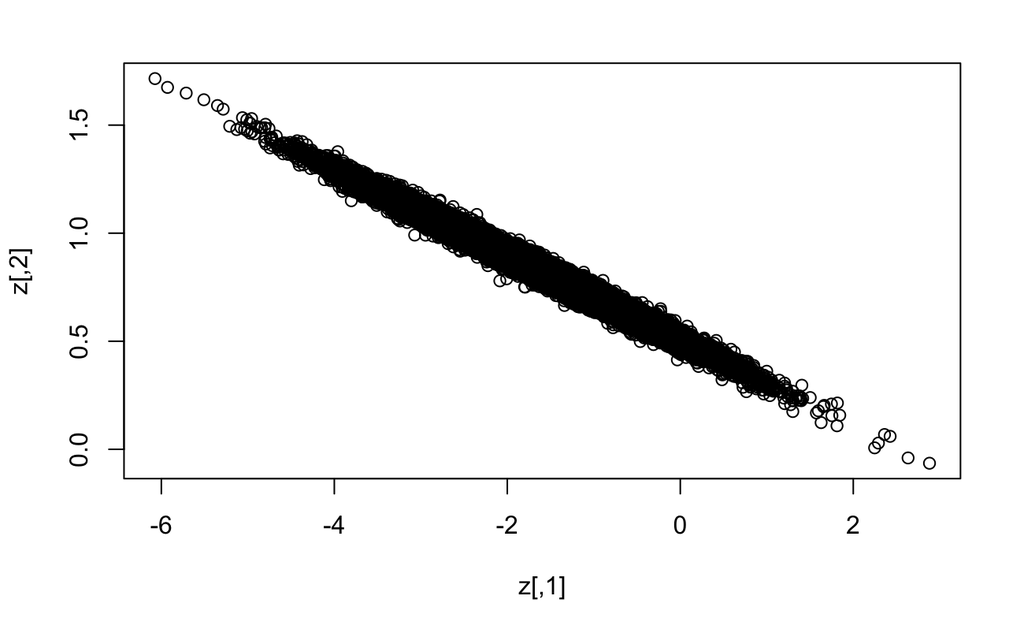

```r
plot(z)
```

### Resumen de estimadores

```r
out.sum<-ej3.sim$BUGSoutput$summary
print(out.sum)
```

```
               mean        sd       2.5%        25%        50%        75%      97.5%
beta[1]  -1.6990977 0.7708967 -3.2234454 -2.1962608 -1.7013780 -1.1959428 -0.1766335
beta[2]   0.8399086 0.1528419  0.5381704  0.7403394  0.8400793  0.9384068  1.1425541
deviance 24.5962978 2.6591902 21.5945226 22.6643808 23.8993444 25.7868870 31.4977673
tau       5.2759574 1.7580445  2.4061946  4.0117664  5.0879290  6.3275251  9.2437875
yf[1]     2.9217006 0.4788690  1.9716958  2.6106454  2.9215752  3.2335953  3.8692002
yf[2]     2.3337827 0.4748776  1.3912544  2.0257955  2.3345921  2.6426880  3.2705548
yf[3]     2.2506850 0.4785009  1.2978853  1.9387766  2.2511911  2.5620026  3.2012211
yf[4]     1.5791463 0.5029720  0.5852086  1.2514030  1.5789569  1.9052138  2.5791372
yf[5]     2.0784229 0.4798610  1.1274581  1.7686764  2.0785301  2.3894024  3.0281595
yf[6]     3.5066671 0.5077714  2.4967904  3.1765641  3.5042167  3.8351384  4.5161402
yf[7]     3.3382409 0.4982040  2.3564085  3.0138192  3.3365490  3.6612842  4.3192651
yf[8]     2.6673390 0.4740454  1.7309193  2.3601795  2.6643505  2.9753307  3.6098665
yf[9]     2.2495186 0.4746883  1.3021675  1.9423830  2.2490774  2.5588852  3.1912724
yf[10]    1.9118887 0.4848257  0.9567356  1.5970633  1.9120901  2.2249467  2.8772292
yf[11]    2.4145851 0.4733693  1.4738780  2.1085897  2.4145250  2.7211335  3.3537012
yf[12]    2.8346557 0.4780539  1.8887524  2.5248391  2.8344718  3.1444562  3.7813431
yf[13]    2.5019796 0.4712181  1.5699587  2.1962009  2.5015709  2.8086688  3.4340433
yf[14]    3.5959303 0.5116015  2.5852701  3.2642640  3.5940333  3.9280191  4.6144473
yf[15]    2.1649942 0.4767090  1.2212217  1.8544140  2.1656653  2.4774548  3.1072211
yf[16]    1.9114022 0.4841196  0.9587745  1.5974572  1.9102158  2.2244340  2.8727643
yf[17]    2.4994340 0.4743294  1.5616150  2.1929875  2.4977169  2.8078942  3.4380542
yf[18]    3.2568377 0.4905729  2.2842058  2.9407585  3.2571813  3.5720692  4.2267817
yf[19]    1.7443272 0.4953653  0.7503556  1.4243326  1.7441615  2.0653087  2.7203015
yf[20]    2.2507185 0.4752655  1.3145282  1.9421211  2.2525015  2.5605546  3.1929761
```

```r
head(out.sum)
```

```
               mean        sd       2.5%        25%        50%        75%      97.5%
beta[1]  -1.6990977 0.7708967 -3.2234454 -2.1962608 -1.7013780 -1.1959428 -0.1766335
beta[2]   0.8399086 0.1528419  0.5381704  0.7403394  0.8400793  0.9384068  1.1425541
deviance 24.5962978 2.6591902 21.5945226 22.6643808 23.8993444 25.7868870 31.4977673
tau       5.2759574 1.7580445  2.4061946  4.0117664  5.0879290  6.3275251  9.2437875
yf[1]     2.9217006 0.4788690  1.9716958  2.6106454  2.9215752  3.2335953  3.8692002
yf[2]     2.3337827 0.4748776  1.3912544  2.0257955  2.3345921  2.6426880  3.2705548
```

### Si quiero estimar de manera puntual Beta1: esta alrededor de -1.7 con un desvío de 0.77. Beta 2: alrededor de 0.84 con un desvio de 0.15.Como esta es la media, es la funcion de pérdida cuadrática la que estoy usando para mi función de pérdida.

### Lo que mas me va a importar son los intervalos de estimacion de credibilidad del 95%:

### Beta1 [ -3.23 - -0.17]

### Beta2 [ 0.53 - 1.14]

### Existe otro indicador que me es más útil para tomar la decisión de si un coeficiente está cercano a cero o no. La probabilidad de que Beta1 sea menor a cero?. Y esta es la distribución final

### Probabilidades

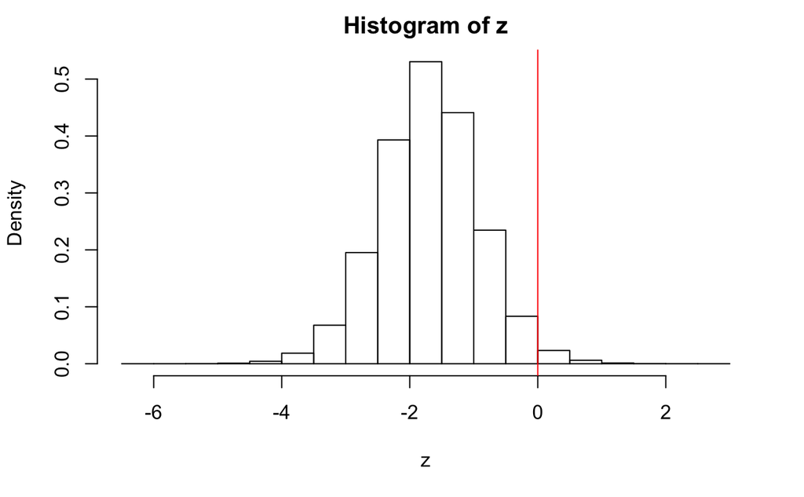

```r
z<-out$beta[,1]
hist(z,freq=FALSE)
abline(v=0,col=2)
```

```r
1 - prob(z)
```

```
[1] 0.9845889
```

### La probabilidad de que Beta1 sea menor a cero es 0.98, 98%, es mas que el 95% que vimos en los intervalos. Entonces mi coeficiente Beta1 es significativamente distinto de cero. La proba es chiquita lo tomo, asi es como se interpreta mi valor “p”.

### DIC

```r
out.dic<-ej3.sim$BUGSoutput$DIC
print(out.dic)
```

```
[1] 28.13194
```

### NOTA: Siempre es importante escalar los datos si están en escalas muy chicas o muy grandes para resolver problemas numéricos.

### Predicciones: el vector out.sum contiene todas las predicciones y quiero filtrar solo las yf para poder graficarlas

```r
out.yf2<-out.sum[grep("yf",rownames(out.sum)),]
or<-order(calif$MO)
ymin<-min(calif$SP,out.yf2[,c(1,3,7)])
ymax<-max(calif$SP,out.yf2[,c(1,3,7)])
par(mfrow=c(1,1))
plot(calif$MO,calif$SP,ylim=c(ymin1,ymax1))
lines(calif$MO[or],out.yf1[or,1],lwd=2,col=1)
```

[output not shown]

```r
lines(calif$MO[or],out.yf1[or,3],lty=2,col=1)
lines(calif$MO[or],out.yf1[or,7],lty=2,col=1)
```

[output not shown]

```r
lines(calif$MO[or],out.yf2[or,1],lwd=2,col=2)
lines(calif$MO[or],out.yf2[or,3],lty=2,col=2)
```

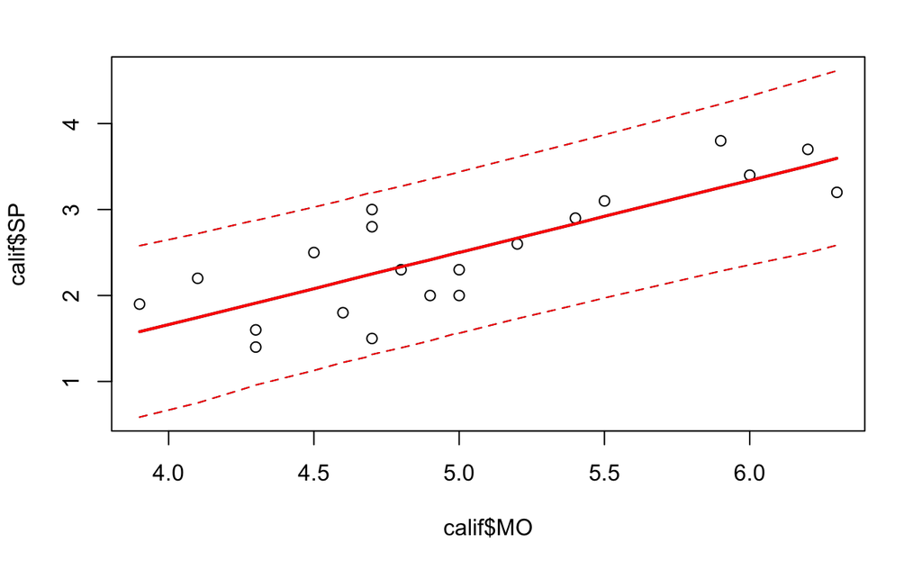

```r
lines(calif$MO[or],out.yf2[or,7],lty=2,col=2)
```

### Aqui tenemos graficados el estimador puntual (raya continua) y nuestros intervalos de predicción (lineas punteadas). Si nuestros intervalos de predicción contienen a los valores estimados, como en este caso todos los puntos están contenidos, entonces mi modelo es bueno.